# EVD Outcome Modeling and Predictor Analysis

We conducted a comprehensive analysis to identify predictors of Ebola Virus Disease (EVD) outcomes and complications.  
A **stepwise modeling workflow** was applied, including data cleaning, univariate screening, collinearity assessment, LASSO selection, and multivariable regression, to ensure robust predictor identification.  
To enhance interpretability and model power, clinically overlapping symptoms were grouped into coherent categories.

**Receiver Operating Characteristic (ROC)** analyses were used to determine optimal cycle threshold (Ct) values for predicting outcomes.  
Independent predictors were quantified using **Poisson regression** with robust standard errors (adjusted risk ratios, aRR) and logistic regression (odds ratios, OR), with results presented for death, treatment subgroups, and key complications.

The following sections present detailed outputs, including:  
- Symptom grouping tables for enhanced interpretability,  
- ROC curves and threshold analyses,  
- Multivariable Poisson regression panels for death and complications,  
- Global multivariable logistic regression tables and forest plots combining all selected predictors.

## Method

To analyze the predictors of EVD outcome and complications, we propose this **Directed Acyclic Graphs (DAG)**1 to illustrate hypothesized causal relationships underlying **EVD pathophysiology and clinical outcomes**.

[interactive chart not shown]

Figure 1: Directed Acyclic Graphs (DAG)

### Proposed Grouping of Variables

To account for overlapping clinical features, we grouped similar symptoms into broader categories. This approach aimed to **increase model power and interpretability by reducing sparse variables** while capturing clinically coherent syndromic patterns.

**Table 1. Symptom grouping used for analysis**

| Category | Variables |
| --- | --- |
| CNS signs | agitation_anytime, coma_p_u_in_avpu_scoring, coma, desorientation_anytime, seizure_anytime, headache_anytime, irritability_confusion_anytime |
| Bleeding signs | unusual_bleeding_bruising_anytime, bleeding |
| Gastrointestinal signs | diarrhoea_anytime, nausea_vomiting_anytime, abdominal_pain_anytime, anorexia_anytime, dysphagia_anytime |
| Renal signs | renal_impairment, anuria_anytime |
| Dehydration signs | anuria_anytime, signs_of_dehydration_anytime |

### ROC Analysis

Next, **Receiver Operating Characteristic (ROC)** analyses were performed to determine the optimal cycle threshold (Ct) value for predicting participant outcomes.  
With an **area under the curve (AUC)** of 0.85, ROC analysis identified **a Ct cut-off of 23.25** as the optimal threshold to discriminate outcomes, achieving a sensitivity of 79% and a specificity of 77%.  
See 2 for the ROC curve visualization.

[interactive chart not shown]

Figure 2: ROC curve for predicting outcome

### Stepwise Approach to Modeling Outcomes and Complications

We implemented a structured, stepwise modeling workflow (3) to identify independent predictors of clinical outcomes and complications.

**Data cleaning and wrangling** — All datasets were harmonized and inspected for inconsistencies, missing values, and implausible entries using the **tidyverse** R packages (Wickham et al. 2019).

**Univariate screening** — Each predictor was first evaluated in a univariate logistic regression model. Variables with sparse categories or those causing quasi-complete separation were excluded.

**Collinearity assessment** — Remaining variables were tested for multicollinearity using the **car** package and Variance Inflation Factor (GVIF) metrics (Fox and Weisberg 2019). Predictors with generalized VIF (GVIFscaled) values ≤ 1.68 were retained.

**LASSO regression** — To refine the model, Least Absolute Shrinkage and Selection Operator (LASSO) regression was applied using the **glmnet** package (J. Friedman and Tibshirani 2021), shrinking weak predictors and retaining the strongest associations.

**Multivariable logistic regression** — Predictors selected by LASSO were entered into multivariable logistic regression models to estimate adjusted odds ratios (OR) with 95% confidence intervals.

**Computation of risk ratios** — For interpretability, adjusted risk ratios (RR) were derived from robust Poisson regression models using the **sandwich** and **lmtest** packages (Zeileis 2020; Hothorn and Zeileis 2020). Raw (unadjusted) RRs were also calculated for binary predictors.

All analyses were conducted in **R version 4.4.1** (R Core Team 2023). This stepwise approach ensured model parsimony, minimized overfitting, and enhanced interpretability.

This stepwise approach ensured model parsimony, minimized overfitting, and enhanced interpretability.

[interactive chart not shown]

Figure 3: Stepwise Approach to Modeling Outcomes and Complications

## Independent Predictors of EVD Outcome and Complications

Adjusted risk ratios (aRR) and 95% confidence intervals were estimated using **multivariable Poisson regression with robust standard errors**. Predictors for each outcome and complication were selected based on the stepwise modeling workflow described above.

The resulting aRRs are displayed in interactive panels for different outcomes: **death**, **death among treated patients**, and complications including **renal failure** and **bleeding**. Each table presents the adjusted risk ratio and 95% confidence interval for all non-intercept predictors.

Analyses were implemented in R using the `glm()` function with a log link, robust standard errors from the `sandwich` package, and exponentiated coefficients to obtain interpretable risk ratios.

Death Outcome

| Variable | Reported | Relative Risk (95% CI) | Direction |
| --- | --- | --- | --- |
| CT at Admission |  | 0.86 (0.84-0.89) | ⬇ |
| Admission Delay |  | 1.02 (1.01-1.04) | ⬆ |
| Remdesivir (GS-5734) |  | 1.67 (1.2-2.33) | ⬆ |
| Zmapp |  | 1.43 (0.95-2.16) | ↔ |
| REGN3470-3471-3479 |  | 1.04 (0.72-1.51) | ↔ |
| No Treatment |  | 1.53 (0.92-2.53) | ↔ |
| Bleeding Signs | 107/358 | 1.23 (0.99-1.52) | ↔ |
| Rhabdomyolysis | 19/358 | 1.13 (0.81-1.58) | ↔ |
| Severe Hypoglycemia |  | 1.68 (0.78-3.62) | ↔ |
| Signs of Renal Impairment | 49/358 | 1.03 (0.73-1.44) | ↔ |

Death Outcome among Treated

| Variable | Reported | Relative Risk (95% CI) | Direction |
| --- | --- | --- | --- |
| CT at Admission |  | 0.87 (0.84-0.89) | ⬇ |
| NA |  | 2.17 (1.26-3.74) | ⬆ |
| NA |  | 1.84 (1.06-3.17) | ⬆ |
| Remdesivir (GS-5734) |  | 1.67 (1.21-2.3) | ⬆ |
| REGN3470-3471-3479 |  | 1 (0.69-1.45) | ↔ |
| Zmapp |  | 1.5 (0.98-2.3) | ↔ |
| Neurological Signs |  | 0.87 (0.7-1.09) | ↔ |
| Bleeding Signs | 102/346 | 1.19 (0.94-1.5) | ↔ |
| GastroIntestinal Signs |  | 0.63 (0.39-0.99) | ⬇ |
| Rhabdomyolysis | 19/346 | 1.13 (0.8-1.6) | ↔ |
| Severe Hypoglycemia |  | 1.67 (0.82-3.38) | ↔ |
| Signs of Renal Impairment |  | 1.02 (0.72-1.44) | ↔ |

Complications: Renal Failure

| Variable | Reported | Relative Risk (95% CI) | Direction |
| --- | --- | --- | --- |
| Age 5-17 |  | 0.18 (0.02-1.46) | ↔ |
| Age 35-49 |  | 1.35 (0.8-2.27) | ↔ |
| CT at Admission |  | 0.96 (0.91-1) | ↔ |
| Pregnancy | 16/358 | 2.01 (0.89-4.51) | ↔ |
| REGN3470-3471-3479 |  | 1.2 (0.73-1.97) | ↔ |
| No Treatment |  | 0 (0-0) | ⬇ |
| Hyperkaliemia | 7/358 | 2.23 (0.59-8.38) | ↔ |
| Hypokaliemia | 10/358 | 5.4 (2.81-10.38) | ⬆ |
| Bleeding Signs | 107/358 | 0.54 (0.31-0.96) | ⬇ |
| Signs of Dehydratation | 49/358 | 3.14 (1.71-5.77) | ⬆ |
| Rhabdomyolysis | 19/358 | 4.05 (2.09-7.85) | ⬆ |
| Severe Hypoglycemia | 6/358 | 1.64 (0.38-7.16) | ↔ |

Complications: Bleeding

| Variable | Reported | Relative Risk (95% CI) | Direction |
| --- | --- | --- | --- |
| Age 25-34 |  | 1.5 (1.08-2.08) | ⬆ |
| CT at Admission |  | 0.94 (0.92-0.97) | ⬇ |
| `Treatment Delay More than 5 days` |  | 1.82 (1.01-3.29) | ⬆ |
| `Treatment Delay 3 to 5 days` |  | 1.56 (0.84-2.91) | ↔ |
| Remdesivir (GS-5734) |  | 1.23 (0.89-1.7) | ↔ |
| Zmapp |  | 1.33 (0.78-2.25) | ↔ |
| GastroIntestinal Signs | 312/344 | 2.17 (0.74-6.37) | ↔ |
| Signs of Renal Impairment | 49/344 | 0.59 (0.35-0.98) | ⬇ |
| Signs of Dehydratation | 47/344 | 1.75 (1.21-2.52) | ⬆ |
| Hypokaliemia |  | 0.48 (0.07-3.31) | ↔ |

## Global Multivariable Model of EVD Outcomes

To provide an integrated view of all predictors, we fitted a **global multivariable logistic regression model** using all selected variables (`glm()` with binomial family). Adjusted odds ratios (OR) and 95% confidence intervals were computed from exponentiated coefficients, while **adjusted risk ratios (aRR)** and raw RRs were also derived using robust standard errors from the `sandwich` package.

The final table presents:  
- **Adjusted ORs** with 95% CI  
- **Adjusted RRs** with 95% CI  
- **Raw (unadjusted) RRs**  
- Significance indicators (`***`, `**`, `*`, `.`)  
- Direction of association (`⬆` for positive, `⬇` for negative)

A forest plot was added to visualize effect sizes on the log scale, with point estimates and confidence intervals clearly annotated. This combined approach allows for a comprehensive assessment of the independent contribution of each predictor while maintaining interpretability across different measures of association.

Death Outcome

**Characteristic**

**N**

**Event N**

**OR**

**95% CI**

**p-value**

Direction

Unadjusted RR<sup>1</sup>

Adjusted Risk Ratio (95% CI)<sup>2</sup>

CT at admission

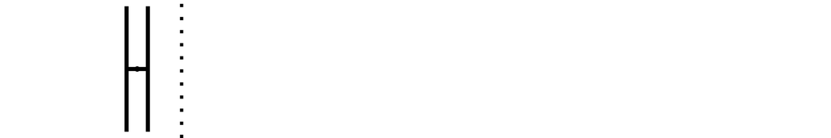

358

134

0.74

0.68, 0.79

<0.001

⬇

0.86 (0.84-0.89)

Delay from Onset to Admission

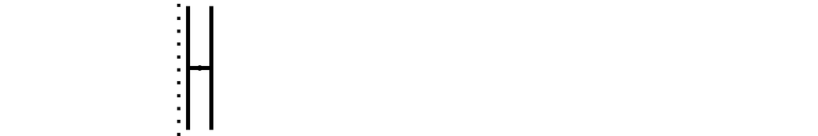

358

134

1.16

1.07, 1.26

<0.001

⬆

1.02 (1.01-1.04)

Remdesivir

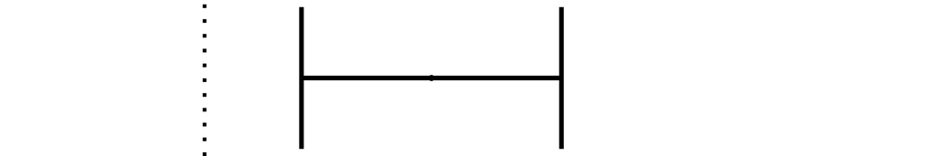

358

134

4.03

1.84, 9.14

<0.001

⬆

1.67 (1.2-2.33)

Zmapp

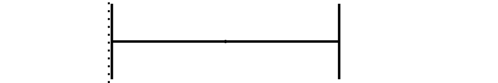

358

134

3.84

1.06, 14.8

0.044

⬆

1.43 (0.95-2.16)

REGN3470-3471-3479

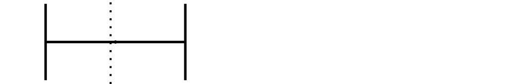

358

134

1.06

0.48, 2.35

0.89

⬆

1.04 (0.72-1.51)

No Treatments

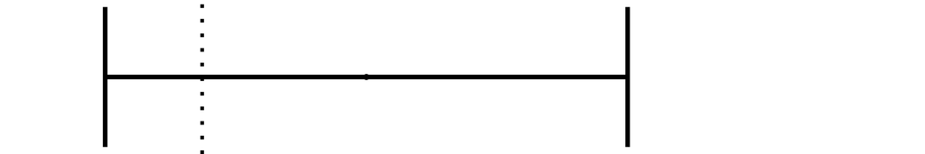

358

134

2.77

0.57, 14.9

0.22

⬆

1.53 (0.92-2.53)

Bleeding Signs

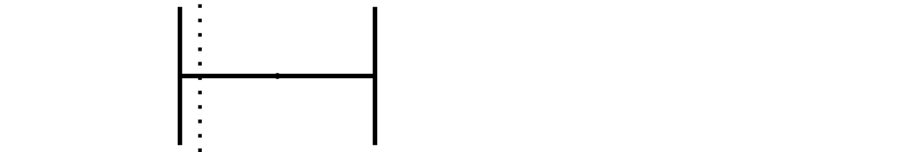

358

134

1.63

0.88, 3.01

0.12

⬆

1.90

1.23 (0.99-1.52)

Rhabdomyolysis

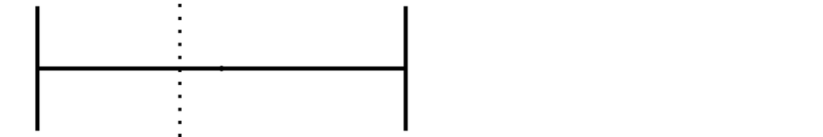

358

134

1.34

0.38, 5.14

0.66

⬆

1.92

1.13 (0.81-1.58)

Severe Hypoglycemia anytime

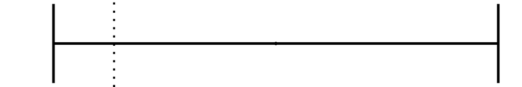

358

134

5.94

0.62, 85.9

0.15

⬆

1.68 (0.78-3.62)

Signs of Renal Impairment

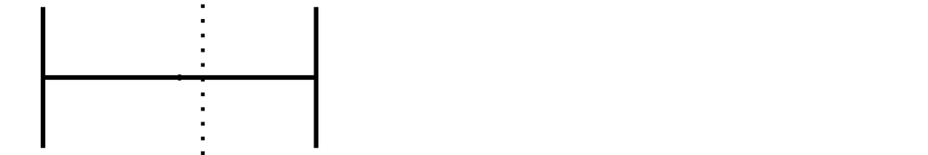

358

134

0.87

0.37, 2.01

0.74

⬇

1.45

1.03 (0.73-1.44)

Abbreviations: CI = Confidence Interval, OR = Odds Ratio, NA

<sup>1</sup> Raw risk ratios (RR) were calculated as the ratio of the risk of death among participants with the condition (Yes) versus without the condition (No).

<sup>2</sup> Adjusted risk ratios (RR) obtained from Poisson regression with robust standard errors. RR > 1 indicates increased risk; RR < 1 indicates decreased risk.

Death Outcome among Treated

**Characteristic**

**N**

**Event N**

**OR**

**95% CI**

**p-value**

Direction

Unadjusted RR<sup>1</sup>

Adjusted Risk Ratio (95% CI)<sup>2</sup>

CT at admission

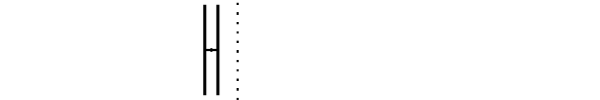

346

128

0.74

0.69, 0.80

<0.001

⬇

0.87 (0.84-0.89)

onset_treatment_daysMore than 5 days

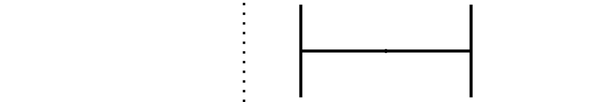

346

128

4.77

1.94, 12.8

0.001

⬆

2.17 (1.26-3.74)

onset_treatment_days3 to 5 days

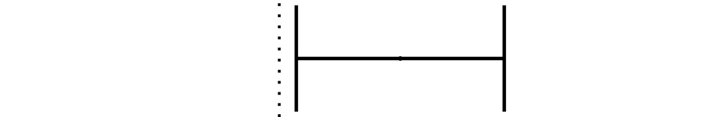

346

128

3.20

1.21, 9.05

0.023

⬆

1.84 (1.06-3.17)

Remdesivir

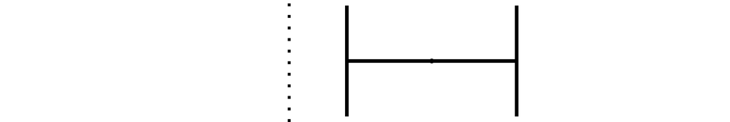

346

128

3.76

1.73, 8.44

<0.001

⬆

1.67 (1.21-2.3)

REGN3470-3471-3479

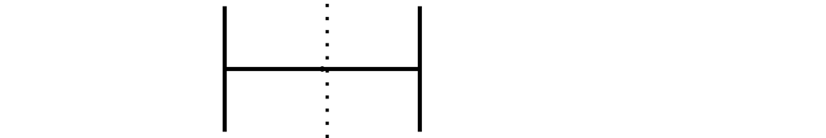

346

128

0.96

0.43, 2.15

0.92

⬇

1 (0.69-1.45)

Zmapp

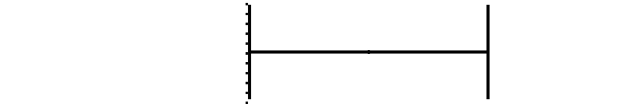

346

128

3.77

1.05, 14.3

0.045

⬆

1.5 (0.98-2.3)

Neurological Signs

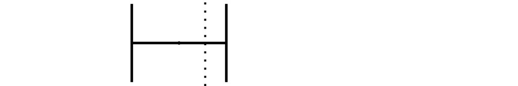

346

128

0.71

0.38, 1.32

0.28

⬇

0.87 (0.7-1.09)

Bleeding Signs

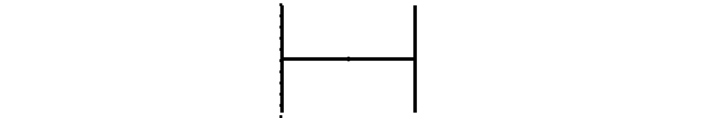

346

128

1.91

1.01, 3.63

0.046

⬆

1.98

1.19 (0.94-1.5)

GastroIntestinal Signs

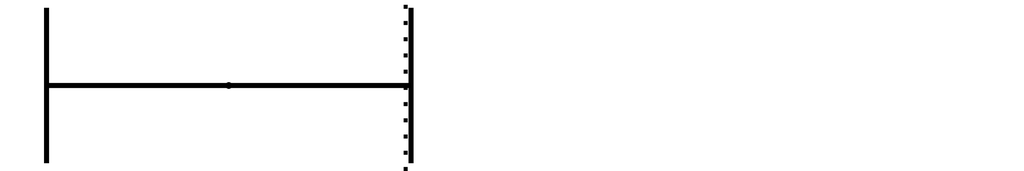

346

128

0.31

0.09, 1.03

0.057

⬇

0.63 (0.39-0.99)

Rhabdomyolysis

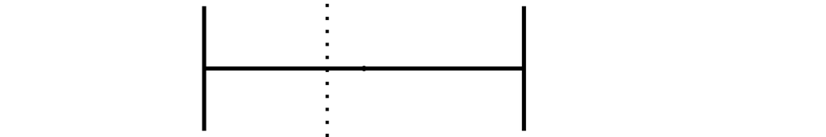

346

128

1.35

0.38, 5.39

0.65

⬆

1.95

1.13 (0.8-1.6)

Severe Hypoglycemia anytime

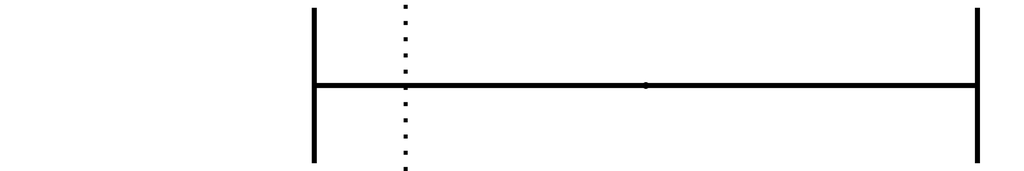

346

128

4.91

0.57, 52.5

0.16

⬆

1.67 (0.82-3.38)

Signs of Renal Impairment

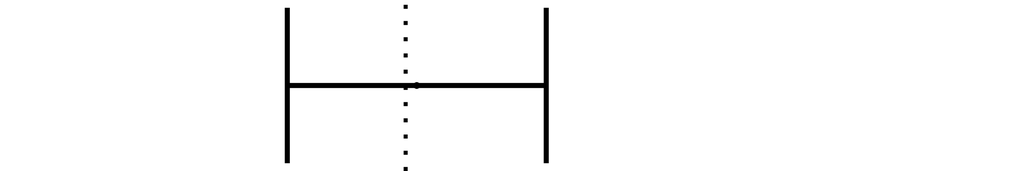

346

128

1.08

0.45, 2.53

0.87

⬆

1.02 (0.72-1.44)

Abbreviations: CI = Confidence Interval, OR = Odds Ratio, NA

<sup>1</sup> Raw risk ratios (RR) were calculated as the ratio of the risk of death among participants with the condition (Yes) versus without the condition (No).

<sup>2</sup> Adjusted risk ratios (RR) obtained from Poisson regression with robust standard errors. RR > 1 indicates increased risk; RR < 1 indicates decreased risk.

Here we included **only patients who received any Ebola experimental treatment** to assess the specific **impact of treatment delay**.

Complications: Renal Failure

| **Characteristic** |  | **N** | **Event N** | **OR** | **95% CI** | **p-value** | Direction | Unadjusted RR<sup>1</sup> | Adjusted Risk Ratio (95% CI)<sup>2</sup> |
| --- | --- | --- | --- | --- | --- | --- | --- | --- | --- |
| Age 5-17 |  | 358 | 49 | 0.04 | 0.00, 0.41 | 0.022 | ⬇ |  | 0.18 (0.02-1.46) |
| Age 35-49 |  | 358 | 49 | 1.51 | 0.65, 3.46 | 0.33 | ⬆ |  | 1.35 (0.8-2.27) |
| CT at admission |  | 358 | 49 | 0.94 | 0.87, 1.00 | 0.074 | ⬇ |  | 0.96 (0.91-1) |
| Pregnancy |  | 358 | 49 | 2.48 | 0.51, 10.5 | 0.23 | ⬆ | 1.90 | 2.01 (0.89-4.51) |
| REGN3470-3471-3479 |  | 358 | 49 | 1.54 | 0.65, 3.61 | 0.32 | ⬆ |  | 1.2 (0.73-1.97) |
| No Treatments |  | 358 | 49 | 0.00 | 0.00, 2,408,873,081 | 0.99 | ⬇ |  | 0 (0-0) |
| hyperkaliemia |  | 358 | 49 | 41.2 | 3.58, 696 | 0.003 | ⬆ | 5.70 | 2.23 (0.59-8.38) |
| hypokaliemia |  | 358 | 49 | 13.3 | 2.36, 76.2 | 0.003 | ⬆ | 3.09 | 5.4 (2.81-10.38) |
| Bleeding Signs |  | 358 | 49 | 0.35 | 0.13, 0.89 | 0.034 | ⬇ | 0.85 | 0.54 (0.31-0.96) |
| Signs of Dehydratation |  | 358 | 49 | 10.5 | 4.14, 27.7 | <0.001 | ⬆ | 4.35 | 3.14 (1.71-5.77) |
| Rhabdomyolysis |  | 358 | 49 | 38.3 | 10.5, 169 | <0.001 | ⬆ | 7.14 | 4.05 (2.09-7.85) |
| Severe Hypoglycemia anytime |  | 358 | 49 | 14.3 | 1.19, 161 | 0.027 | ⬆ | 5.21 | 1.64 (0.38-7.16) |

Abbreviations: CI = Confidence Interval, OR = Odds Ratio, NA  
<sup>1</sup> Raw risk ratios (RR) were calculated as the ratio of the risk of death among participants with the condition (Yes) versus without the condition (No).  
<sup>2</sup> Adjusted risk ratios (RR) obtained from Poisson regression with robust standard errors. RR > 1 indicates increased risk; RR < 1 indicates decreased risk.

Patients with renal impairment had substantially higher odds of developing hyperkalemia compared to those with normal renal function. However, the confidence interval is wide, reflecting the small number of hyperkalemia events.

Complications: Bleeding

**Characteristic**

**N**

**Event N**

**OR**

**95% CI**

**p-value**

Direction

Unadjusted RR<sup>1</sup>

Adjusted Risk Ratio (95% CI)<sup>2</sup>

Age 25-34

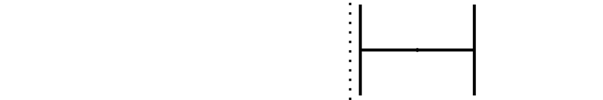

344

102

1.94

1.10, 3.41

0.021

⬆

1.5 (1.08-2.08)

CT at admission

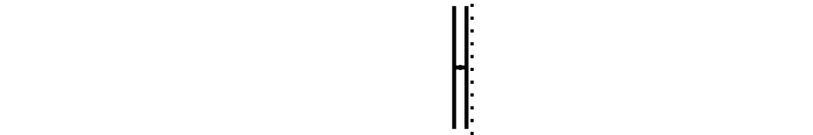

344

102

0.92

0.88, 0.96

<0.001

⬇

0.94 (0.92-0.97)

Delayed Treatment > 5 days

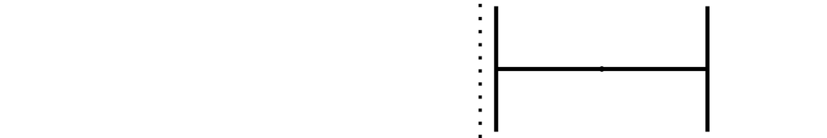

344

102

2.40

1.15, 5.34

0.024

⬆

1.82 (1.01-3.29)

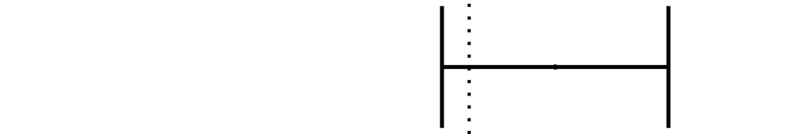

344

102

1.88

0.83, 4.47

0.14

⬆

1.56 (0.84-2.91)

Remdesivir

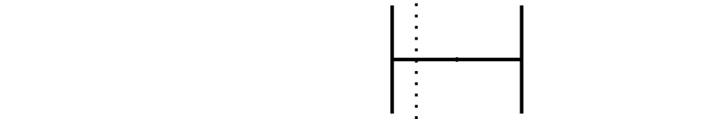

344

102

1.40

0.82, 2.40

0.22

⬆

1.23 (0.89-1.7)

Zmapp

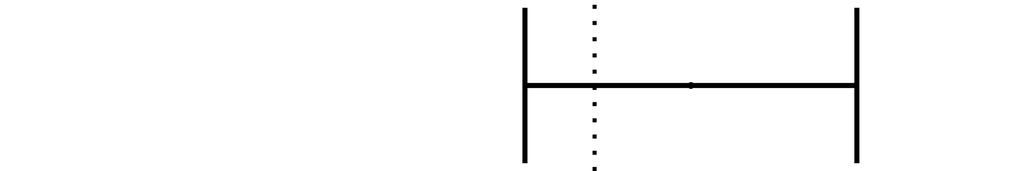

344

102

1.75

0.65, 4.58

0.26

⬆

1.33 (0.78-2.25)

GastroIntestinal Signs

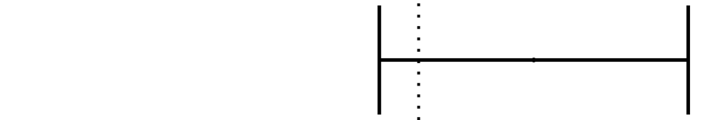

344

102

2.59

0.82, 11.5

0.14

⬆

3.38

2.17 (0.74-6.37)

Signs of Renal Impairment

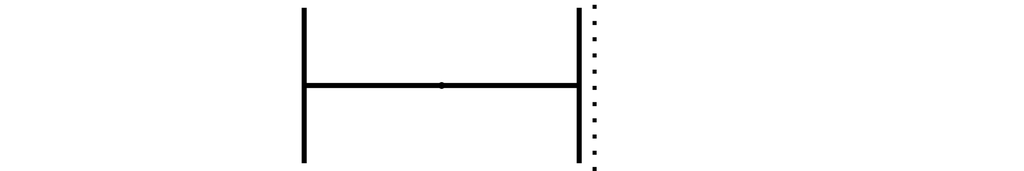

344

102

0.41

0.18, 0.89

0.029

⬇

0.88

0.59 (0.35-0.98)

Signs of Dehydratation

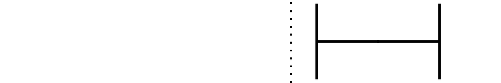

344

102

2.82

1.37, 5.94

0.006

⬆

1.94

1.75 (1.21-2.52)

hypokaliemia

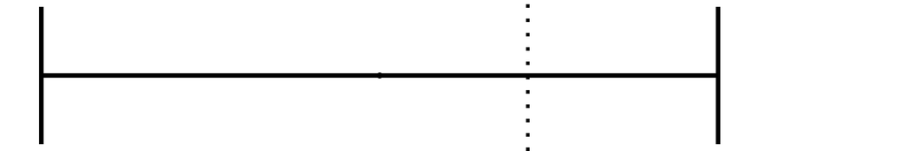

344

102

0.38

0.02, 2.50

0.39

⬇

0.48 (0.07-3.31)

Abbreviations: CI = Confidence Interval, OR = Odds Ratio, NA

<sup>1</sup> Raw risk ratios (RR) were calculated as the ratio of the risk of death among participants with the condition (Yes) versus without the condition (No).

<sup>2</sup> Adjusted risk ratios (RR) obtained from Poisson regression with robust standard errors. RR > 1 indicates increased risk; RR < 1 indicates decreased risk.

Fox, John, and Sanford Weisberg. 2019. *Companion to Applied Regression*. 3rd ed. https://CRAN.R-project.org/package=car.

Hothorn, Torsten, and Achim Zeileis. 2020. *lmtest: Testing Linear Regression Models*. https://CRAN.R-project.org/package=lmtest.

J. Friedman, T. Hastie, and R. Tibshirani. 2021. *glmnet: Lasso and Elastic-Net Regularized Generalized Linear Models*. https://CRAN.R-project.org/package=glmnet.

R Core Team. 2023. *R: A Language and Environment for Statistical Computing*. Vienna, Austria: R Foundation for Statistical Computing. https://www.R-project.org/.

Wickham, Hadley et al. 2019. *Welcome to the tidyverse*. https://www.tidyverse.org/.

Zeileis, Achim. 2020. *sandwich: Robust Covariance Matrix Estimators*. https://CRAN.R-project.org/package=sandwich.